# R Notebook

The main point of the exercises in this chapter is to emphasize the difference between random effects and fixed effect and how they manifest themselves in modelling. random effects are dependent, while fixed effects are independent. We can see this in the code describing the models:

```r
file.show(here("models","random.model.txt"))
file.show(here("models","fixed.model.txt"))
```

In the fixed model the population means are an unknown prior, while in the random effects model the population means are normally distributen around a grand mean. The effect of population on the response in the random effects model is dependent on the grand mean, while completely independent in the fixed effects model.

```r
library(here)
library(rjags)
library(ggplot2)
library(dplyr)
library(reshape2)
theme_set(theme_classic())
```

Before we begin, we load all necessary packages.

### 1. Convert the ANOVA to an ANCOVA (analysis of covariance):

Within the fixed-effects ANOVA, add the effect on SVL of a continuous measure of habitat quality that varies by individual snake (perhaps individuals in better habitat are larger and more competitive). You may either recreate a new dataset that contains such an effect or simply create a habitat covariate (e.g., by drawing random numbers) and add it as a covariate into the previous analysis.

The following Code creates a new dataset with a covariate habitat cover. I have chosen an additive model with a fairly strong relationship between cover and SVL in addition to the population effects.

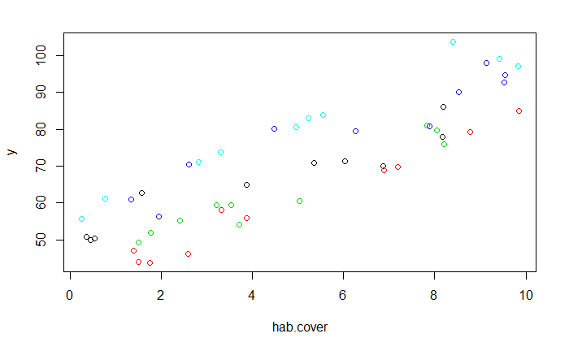

```r
set.seed(1001)
ngroups <- 5                                  # Number of populations
nsample <- 10                                 # Number of snakes in each
pop.means <- c(50, 40, 45, 55, 60)    # Population mean SVL
sigma <- 3                                  # Residual sd
beta <- 4
n <- ngroups * nsample                    # Total number of data points
eps <- rnorm(n, 0, sigma)               # Residuals
x <- rep(1:5, rep(nsample, ngroups))    # Indicator for population
hab.cover <- runif(n, 0, 10)           # Draw random covers
means <- rep(pop.means, rep(nsample, ngroups))
X <- as.matrix(model.matrix(~ as.factor(x) + hab.cover -1)) # Create design matrix
y <- as.numeric(X %*% as.matrix(c(pop.means, beta)) + eps)
plot(hab.cover,y, col = x)
```

The next plot shows that the populations still have quite different means

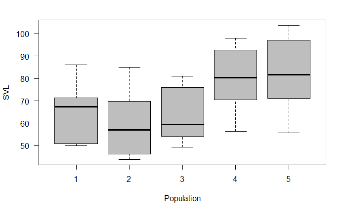

```r
boxplot(y~x, col="grey", xlab="Population", ylab="SVL", main="", las = 1)
```

Write the BUGS model. We just added the effect of habitate cover into the likelihood and defined a prior. I opted to choose a wide uniform prior for beta.

```r
model<-"
model {
# Likelihood
 for (i in 1:n) {
    y[i] ~ dnorm(mean[i], tau)
    mean[i] <- pop.mean[x[i]] + beta * hab.cover[i]
 }
# Priors
 for (i in 1:npop){
    pop.mean[i] ~ dunif(0, 100)
 }
 sigma ~ dunif(0, 100)
 beta ~ dunif(-100,100)
# Derived quantities
 tau <- 1 / ( sigma * sigma)
}
"
model.spec <- textConnection(model)
```

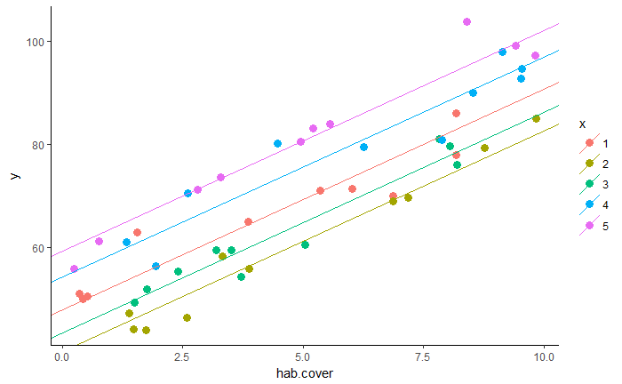

```r
mcmc <- do.call(rbind, Samples)
plotdata <- data.frame(hab.cover = hab.cover,
           y=y, x=as.factor(x), slope = colMeans(mcmc)[1],
           intercept = rep(colMeans(mcmc)[2:6],rep(10,5)))
ggplot(plotdata)+geom_point(aes(x = hab.cover, y = y, color = x), size = 3)+
  geom_abline(aes(intercept = intercept, slope = slope, color = x))
```

```r
rbind(colMeans(mcmc)[2:6], pop.means)
```

```
          pop.mean[1] pop.mean[2] pop.mean[3] pop.mean[4] pop.mean[5]
             47.79585    39.69184    43.32721    54.13397    59.26338
pop.means    50.00000    40.00000    45.00000    55.00000    60.00000
```

### 2. Watch shrinkage happen:

Population mean estimates under the random- effects ANOVA are shrunk toward the grand mean when compared with those under a fixed-effects model. First, watch this shrinkage by fitting a fixed-effects ANOVA to the random-effects data simulated in Section 9.3.1. Second, discard the data from 8 out of 10 snakes in one population and see what happens to the estimate of that population mean.

```r
plotdata <- data.frame(means = c(colMeans(rdata.rmodel)[2:11],colMeans(rdata.fmodel)[1:10]),
                      pop = rep(1:10,2),
                      col = rep(c("random", "fixed"), c(10,10)))
bigdata <- ggplot(plotdata) + geom_point(aes(x = pop, y = means, color = col), size = 3) + geom_hline(yintercept = colMeans(rdata.rmodel)[1])
```

Discard 8 out of 10 datapoints

```r
ind <- seq(1, 120, by = 6)
y <- y[ind]
x <- x[ind]
#boxplot(y ~ x, col = "grey", xlab = "Population", ylab = "SVL", main = "", las = 1)
#abline(h = pop.grand.mean)
```

The population mean estimates have moved towards the grand mean. Overall our estimates are much noisier, as seen in the grand mean estimate.

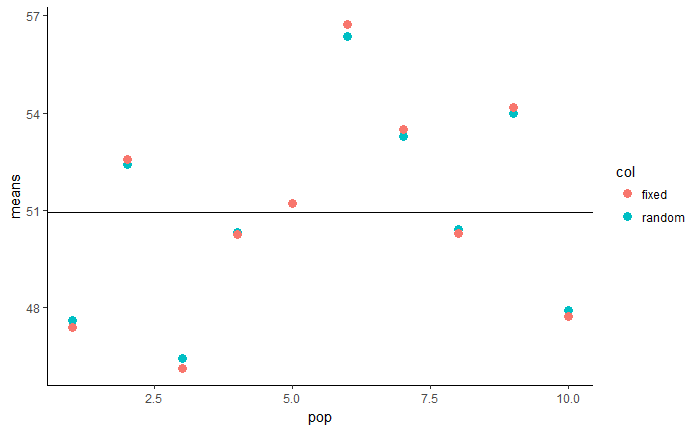

```r
bigdata
```

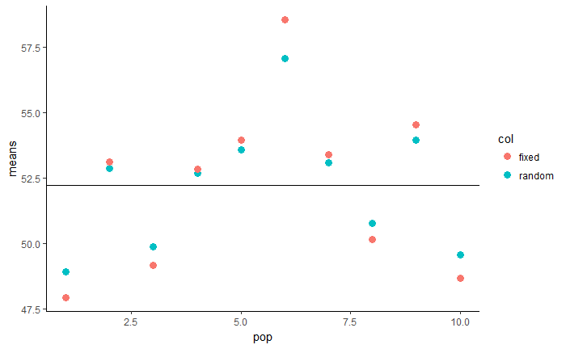

```r
smalldata
```

### 3. Swiss haredata:

Compare mean observed population density among all surveyed sites when treating years as replicates. Do this once assuming that these populations corresponded to fixed effects; then repeat the analysis assuming they are random effects.

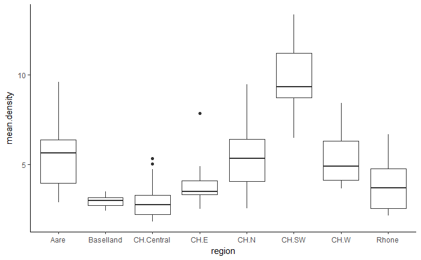

```r
hares <- read.table(file = here("data","hares.data.txt"), header = TRUE)
hares. <- hares %>%
  filter(!is.na(mean.density))%>% # filter out NAs
  group_by(region, year) %>%
  summarize(mean.density = mean(mean.density))
ggplot(hares., aes(x = region, y = mean.density)) + geom_boxplot()
```

This plot gives an overview of the data

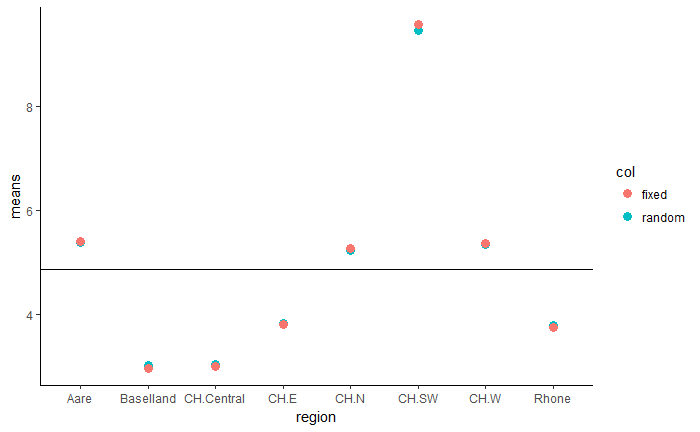

```r
hares.plot.gg
```

We don’t see much shrinkage looking at the data this way. There is some movement in three regions towards the grand mean.

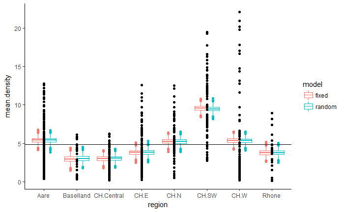

To show the effects of shrinkage again. I rerun the analyses estimating the average mean density across all sites of the years.

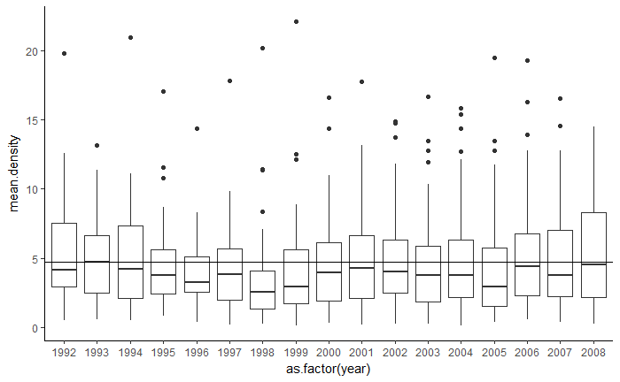

```r
ggplot(hares) + geom_boxplot(aes(x = as.factor(year), y = mean.density)) +
  geom_hline(yintercept = mean(hares$mean.density, na.rm = T))
```

This is how the raw data looks.

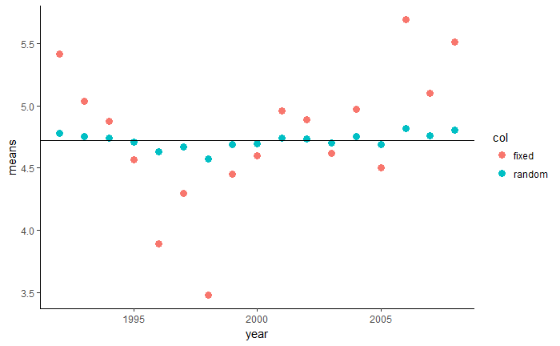

```r
hares.plot.gg
```

We see clear shrinkage of the random model estimate towards the mean

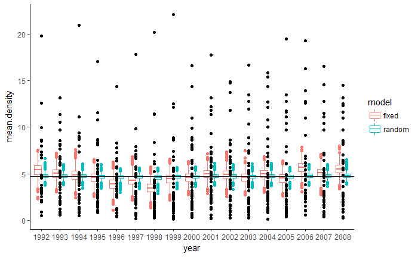

```r
df <- melt(haresdata.rmodel[,2:18])
df2 <- melt(haresdata.fmodel[,1:17])
levels(df$Var2)<-c(1992:2009)
levels(df2$Var2)<-c(1992:2009)
df$model <- "random"
df2$model <- "fixed"
df3 <- rbind(df,df2)
colnames(df3) <- c("ID", "year", "mean.density", "model")
ggplot(df3) + geom_boxplot(aes(x = year, y = mean.density, color = model)) +
  geom_point(data = hares, aes(x = as.factor(year), y = mean.density)) +
  geom_hline(yintercept = colMeans(haresdata.rmodel)[1])
```

This time the raw data from the MCMC chains with the original datapoints. The fixed model also seems to capture more of the variation of the different years.